# Mind in the Holographic Field

A Panvibrational Reduction Base for Consciousness

Edward F Hillenaar, MSc.

2022-11-25

# **Introduction**

This ontology of mind and consciousness postulates a **reduction base** by which it can explain how an **image of the external world** is created and experienced. The **panvibrational reduction base** explains and formulates which **psycho-physical laws** are involved (f.e.; Gibson’s invariance laws, optical flow fields, etc.) that explain the generation and perception of a **holographic image** of external events and happenings in, by and of the human mind.

In this ontology of mind and consciousness, the reduction base is called “**Panvibration**” and the underlying crucial psycho-physical laws were first formulated by the late psychologist James Gibson and his work on the nature and psycho-physical mechanisms of **visual perception** (Gibson 1950). The Philosophy of Mind of Henri Bergson (Bergson 1911), (Bergson 1910), (Bergson 1922) also plays a fundamental role in this ontological theory with the **ultimate metaphysical goal** of solving the “**Hard Problem of Consciousness**” (Chalmers 1995).

Other references: (Chalmers and Chalmers 1995), (Robert Lawrence Kuhn 2020)

# **Data**

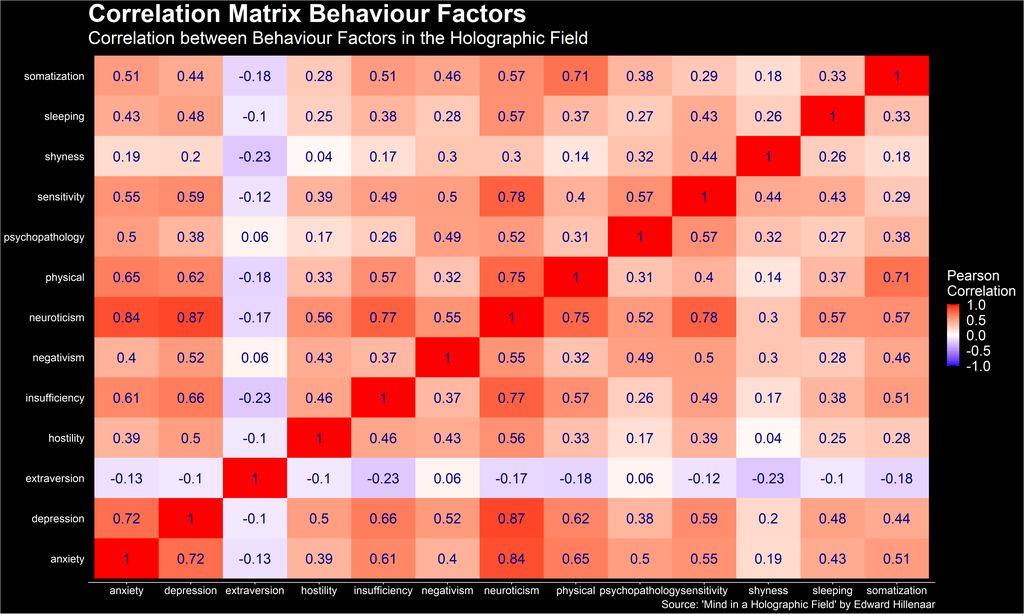

Correlation Matrix of behaviour factors

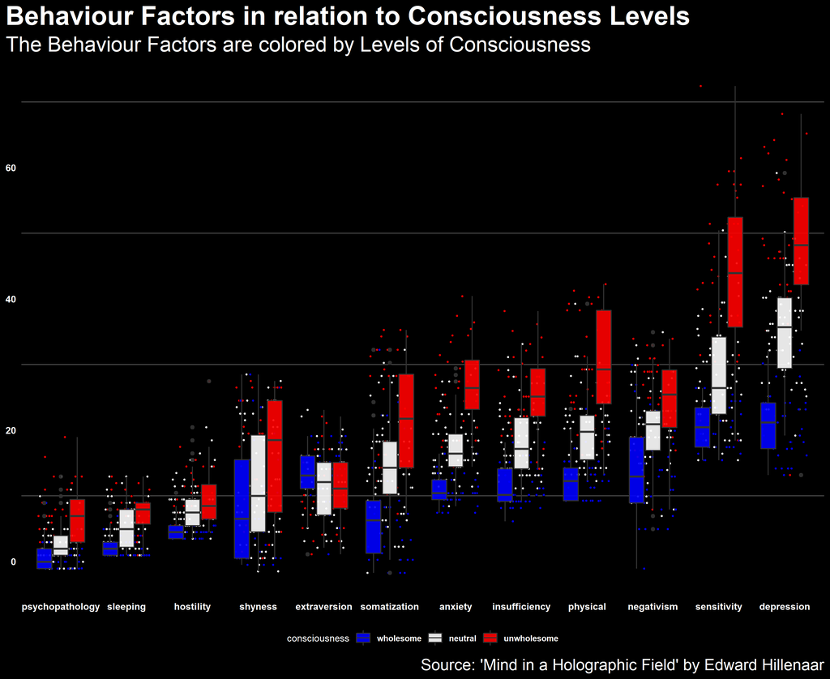

Behaviour Factors in relation to Consciousness Levels

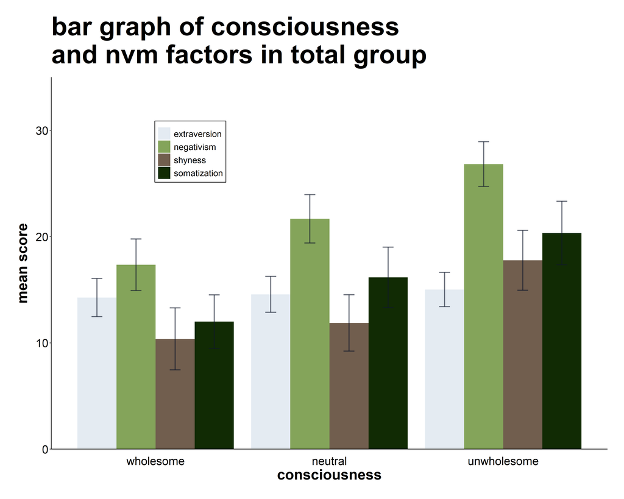

bar graph consciousness and nvm factors in total group

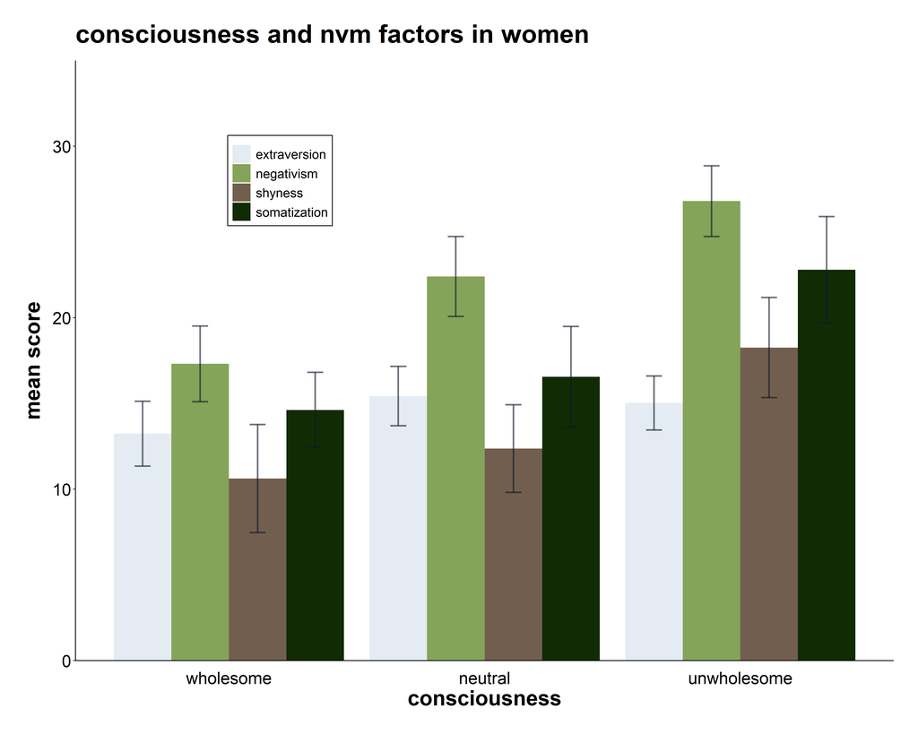

bargraph of consciousness and nvm factors in women

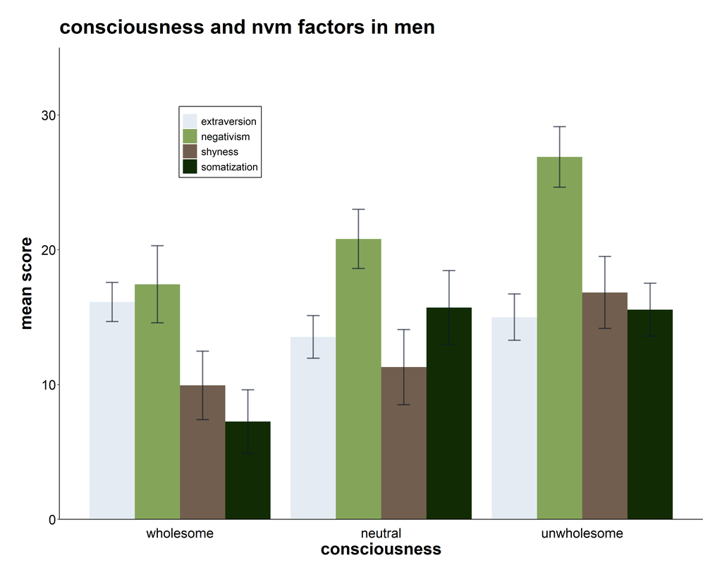

bargraph of consciousness and nvm factors in men

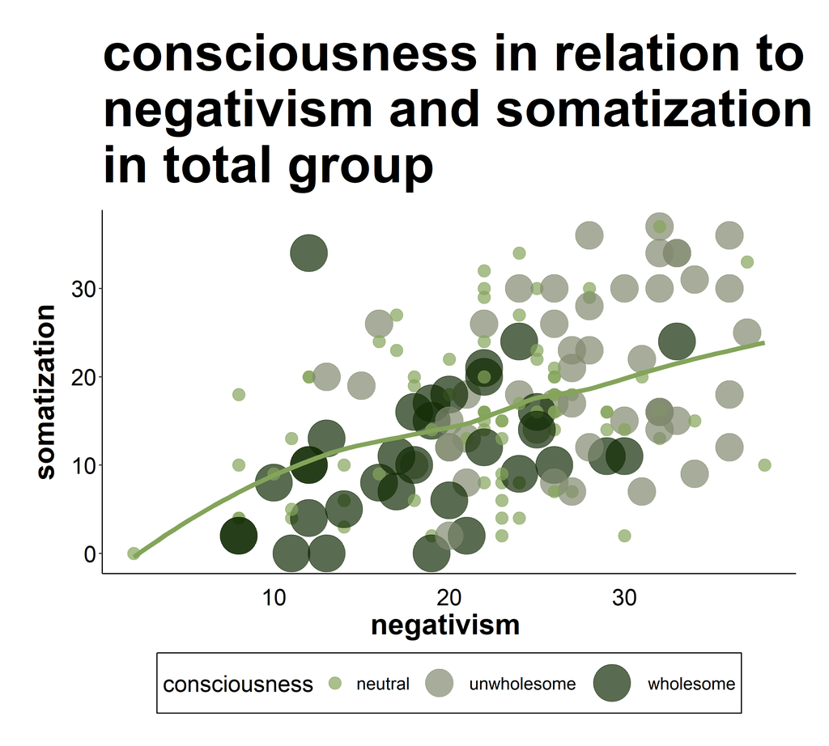

scatterplot consciousness in relation to negativism and somatization in total group

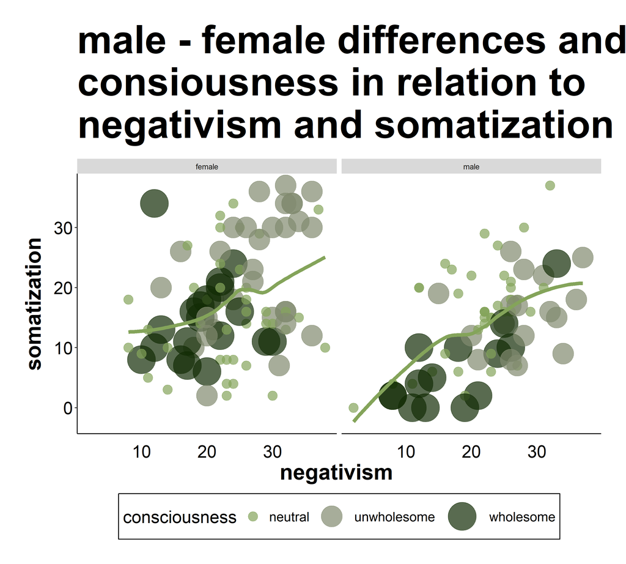

scatterplot male - female differences in consciousness in total nvm group

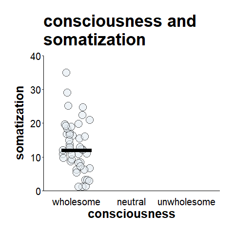

Animation consiousness and somatization in total nvm group

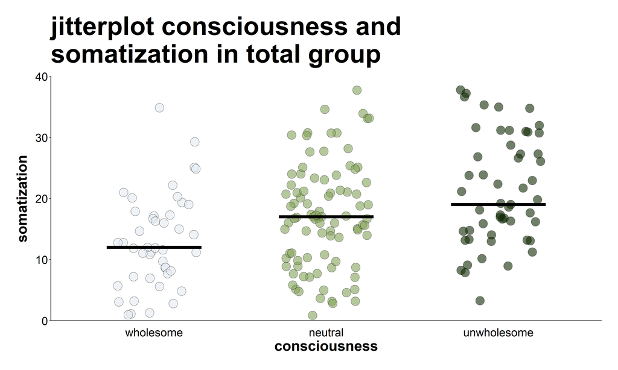

jitterplot of consciousness and somatization in total group

# **References**

Bergson, Henri. 1910. *Time and Free Will: An Essay on the Immediate Data of Consciousness*. Londen: George Allen & Unwin LTD.

———. 1911. *Matter and Memory*. London: George Allen & Unwin LTD.

———. 1922. *Duration and simultaneity: with reference to Einstein’s theory*. New York: The Bobbs-Merrill Company, INC.

Chalmers, David J. 1995. *The Conscious Mind. In Search of a Theory of Conscious Experience*. Oxford: Oxford University Press. https://doi.org/10.1136/bmj.2.5310.969-c.

Chalmers, David J., and David J. Chalmers. 1995. “Facing Up to the Problem of Consciousness.” *Journal of Consciousness Studies* 2 (3): 200–219. https://doi.org/10.1093/acprof:oso/9780195311105.003.0001.

Gibson, James J. 1950. *The Perception of the Visual World*. Cambridge: The Riverside Press. https://doi.org/10.2307/2181436.

Robert Lawrence Kuhn. 2020. “Can Brain Alone Explain Consciousness?” Closer to Truth. https://www.youtube.com/watch?v=LyPEgKuqrtM.